# 두 그룹의 통계적 비교

t-검정

Author

최요한

Published

June 26, 2026

# 1 준비사항

## 1.1 학습 목표

**Note**

1. t-검정을 통해 두 평균의 통계적 비교를 배웁니다.
2. pivot_weder, pivot_longer 함수를 사용해 데이터 구성을 변형합니다.
3. ggplot2 갤러리를 활용합니다.
4. treemapify 패키지를 사용해 트리맵을 그립니다.

## 1.2 tidyverse 로드

> 항상 tidyverse를 로드합니다.

```r
library(tidyverse)            # 라이브러리 로드
```

## 1.3 패키지

> 오늘 사용하는 패키지입니다.

```r
# install.packages("treemapify")     # 트리맵
library(treemapify)
```

# 2 t-검정 실습(1)

## 2.1 palmerpenguins

> Adelie, Chinstrap, Gentoo 펭귄의 평균 부리길이, 두께, 체중은?

```r
library(palmerpenguins)
(penguins |>
  group_by(species) |>
  reframe(mean_length = round(mean(bill_length_mm, na.rm = T),1),
          mean_depth = round(mean(bill_depth_mm, na.rm = T), 1),
          mean_mass = round(mean(body_mass_g, na.rm = T), 1),
          n = n()) -> penguins_1_table)
```

```
# A tibble: 3 × 5
  species   mean_length mean_depth mean_mass     n
  <fct>           <dbl>      <dbl>     <dbl> <int>
1 Adelie           38.8       18.3     3701.   152
2 Chinstrap        48.8       18.4     3733.    68
3 Gentoo           47.5       15       5076    124
```

### 2.1.1 visualize

> 시각화를 통해 확인합니다

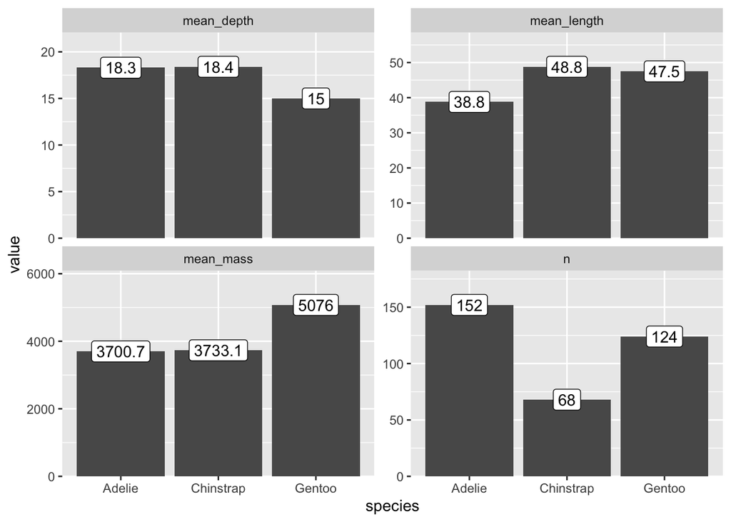

```r
penguins_1_table |>
  pivot_longer(cols = !species,
               names_to = "type",
               values_to = "value") |>
  ggplot(aes(x = species, y = value)) +
  geom_bar(stat = 'identity') +                             # 막대그래프
  facet_wrap(.~type, scales = 'free_y') +                   # 그래프 분할
  geom_label(aes(label = value)) +                          # 값 추가
  scale_y_continuous(expand = expansion(mult = c(0, 0.2)))  # y축 20% 여백 추가
```

## 2.2 t.test

### 2.2.1 Chinstrap vs Gentoo 부리 두께 비교

> Chinstrap 펭귄이 Gentoo 펭귄보다 부리 두께가 평균적으로 3.4mm 더 두껍습니다

> 이것은 통계적으로 유의미한가요? (유의미하게 다른가요?)

```r
(penguins |>
  filter(species %in% c('Gentoo', 'Chinstrap')) -> penguins_Gentoo_Chinstrap)
```

```
# A tibble: 192 × 8
   species island bill_length_mm bill_depth_mm flipper_length_mm body_mass_g
   <fct>   <fct>           <dbl>         <dbl>             <int>       <int>
 1 Gentoo  Biscoe           46.1          13.2               211        4500
 2 Gentoo  Biscoe           50            16.3               230        5700
 3 Gentoo  Biscoe           48.7          14.1               210        4450
 4 Gentoo  Biscoe           50            15.2               218        5700
 5 Gentoo  Biscoe           47.6          14.5               215        5400
 6 Gentoo  Biscoe           46.5          13.5               210        4550
 7 Gentoo  Biscoe           45.4          14.6               211        4800
 8 Gentoo  Biscoe           46.7          15.3               219        5200
 9 Gentoo  Biscoe           43.3          13.4               209        4400
10 Gentoo  Biscoe           46.8          15.4               215        5150
# ℹ 182 more rows
# ℹ 2 more variables: sex <fct>, year <int>
```

```r
t.test(bill_depth_mm ~ species, data = penguins_Gentoo_Chinstrap)
```

```
    Welch Two Sample t-test

data:  bill_depth_mm by species
t = 21.01, df = 122.3, p-value < 2.2e-16
alternative hypothesis: true difference in means between group Chinstrap and group Gentoo is not equal to 0
95 percent confidence interval:
 3.114497 3.762452
sample estimates:
mean in group Chinstrap    mean in group Gentoo
               18.42059                14.98211
```

#### 해석

3.4mm의 차이는 통계적으로 유의미하게 다릅니다.

> t = 21.01

> p-value = < 2.2e-16

> 95 percent confidence interval: 3.114 ~ 3.76

### 2.2.2 Adelie vs Chinstrap 체중 비교

> Chinstrap 펭귄의 체중이 Adelie 펭귄보다 평균 33g 더 무겁습니다

> 이것은 통계적으로 유의미한가요? (유의미하게 다른가요?)

```r
penguins_1_table |>
  filter(species != 'Gentoo') |>
  select(species, mean_mass, n)
```

```
# A tibble: 2 × 3
  species   mean_mass     n
  <fct>         <dbl> <int>
1 Adelie        3701.   152
2 Chinstrap     3733.    68
```

#### t.test() 결과

```r
penguins |>
  filter(species %in% c('Adelie', 'Chinstrap')) -> penguins_Adelie_Chinstrap

t.test(body_mass_g ~ species, data = penguins_Adelie_Chinstrap)
```

```
    Welch Two Sample t-test

data:  body_mass_g by species
t = -0.54309, df = 152.45, p-value = 0.5879
alternative hypothesis: true difference in means between group Adelie and group Chinstrap is not equal to 0
95 percent confidence interval:
 -150.38481   85.53284
sample estimates:
   mean in group Adelie mean in group Chinstrap
               3700.662                3733.088
```

#### 해석

33g의 차이는 통계적으로 유의미하지 않습니다 (체중이 다르다고 하기 어렵습니다)

> p-value = 0.5879

> 95 percent confidence interval: -150.38481 ~ 85.53284
> - 신뢰구간이 0을 지나면 유의미하지 않습니다 (클 때도 있고 작을 때도 있다)

### 2.2.3 Gentoo vs Chinstrap 부리 길이 비교

> 이것은 통계적으로 유의미한가요? (유의미하게 다른가요?)

```r
t.test(bill_length_mm ~ species, data = penguins_Gentoo_Chinstrap)
```

```
    Welch Two Sample t-test

data:  bill_length_mm by species
t = 2.706, df = 129.22, p-value = 0.00773
alternative hypothesis: true difference in means between group Chinstrap and group Gentoo is not equal to 0
95 percent confidence interval:
 0.3572698 2.3006212
sample estimates:
mean in group Chinstrap    mean in group Gentoo
               48.83382                47.50488
```

#### 해석

유의미하게 다릅니다.

> t = 2.706

> p-value = 0.00773

> 95 percent confidence interval: 0.357 ~ 2.300

**Note**

**유의미하게 다르다고 볼수 있다는 것은 어떤 의미일까요?**  
재현성이 있다는 것입니다.

**신뢰구간 0.357 ~ 2.30이 의미하는 바는 무엇일까요?**  
Gentoo 펭귄과 Chinstrap 펭귄의 부리 길이를 여러 차례 표본으로 측정할 경우, 부리 길이 차이는 0.357mm ~ 2.300mm 구간 안에 있을 확률이 95%입니다.

# 3 회귀분석

## 3.1 심슨 패러독스

🔗 [링크](https://namu.wiki/w/%EC%8B%AC%EC%8A%A8%EC%9D%98%20%EC%97%AD%EC%84%A4)

> 펭귄 부리의 길이가 길수록 부리의 두께도 두꺼워질까?

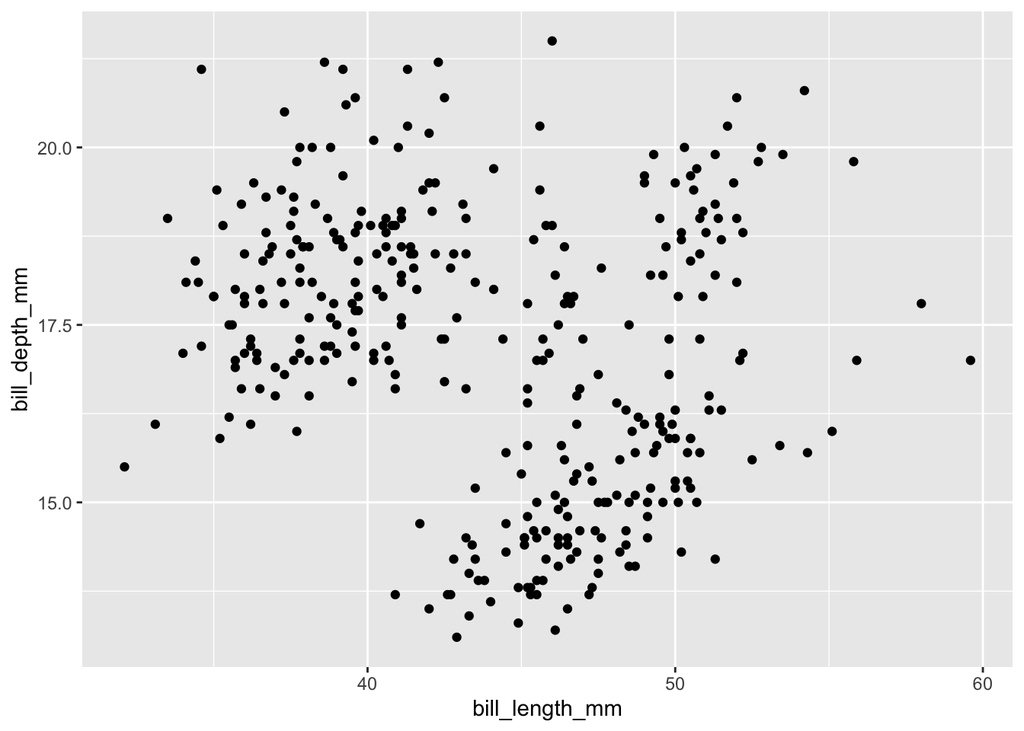

```r
penguins |>
  ggplot(aes(x = bill_length_mm, y = bill_depth_mm)) +
  geom_point()
```

> 추체선을 그려 흩어진 데이터를 해석합니다

> 부리가 길수록 두꺼워지나요?

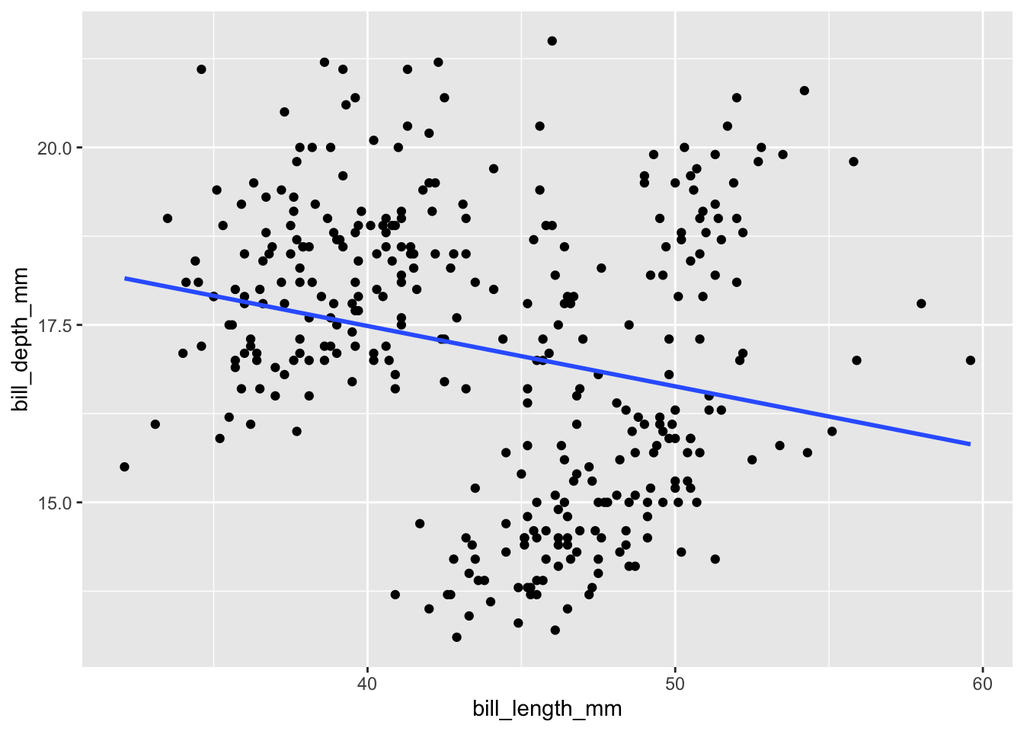

```r
penguins |>
  ggplot(aes(x = bill_length_mm, y = bill_depth_mm)) +
  geom_point() +
  geom_smooth(method = 'lm', se = F)
```

> 종족별로 구분합니다

**소스 코드 확인하기**

```r
penguins |>
  ggplot(aes(x = bill_length_mm, y = bill_depth_mm, color = species)) +
  geom_point() +
  geom_smooth(method = 'lm', se = F)
```

[output not shown]

## 3.2 분산분석 (ANOVA)

> Gentoo vs Chinstrap 부리 길이

> 부리 길이 측정에 성별 차이가 영향을 주었을까?

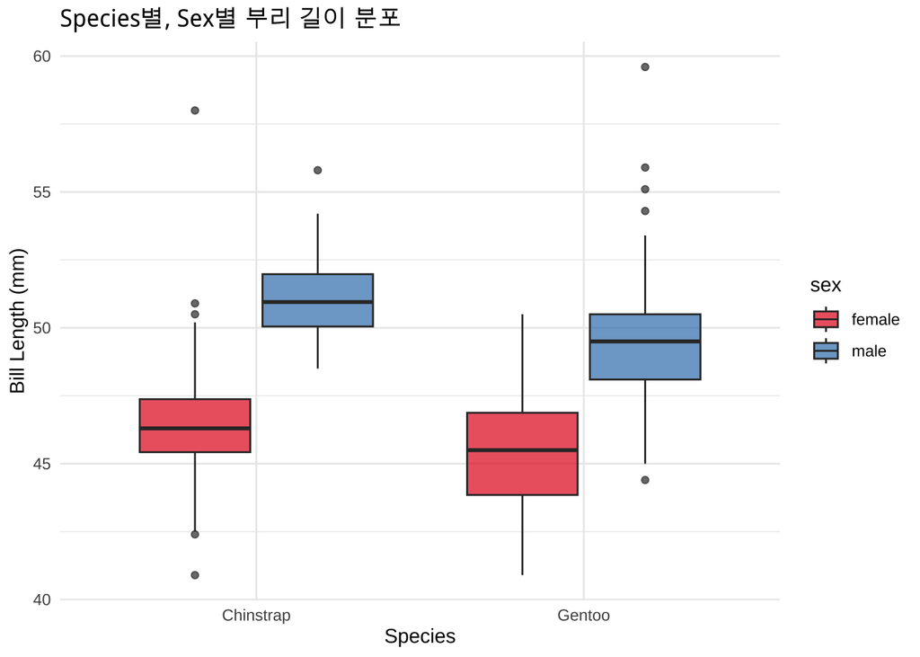

```r
library(showtext)
showtext_auto()

penguins_Gentoo_Chinstrap %>%
  filter(!is.na(sex)) %>%
  ggplot(aes(x = species, y = bill_length_mm, fill = sex)) +
  geom_boxplot(alpha = 0.7) +
  labs(title = "Species별, Sex별 부리 길이 분포",
       x = "Species", y = "Bill Length (mm)") +
  theme_minimal() +
  scale_fill_brewer(palette = 'Set1')
```

> 종과 성별을 모두 포함해 분석하는 ANOVA(Two-way) 를 수행합니다

```r
# 두 변수의 주효과와 상호작용을 함께 검정
anova_result <- aov(bill_length_mm ~ species * sex, data = penguins_Gentoo_Chinstrap)
summary(anova_result)
```

```
             Df Sum Sq Mean Sq F value   Pr(>F)
species       1   69.3    69.3  11.708 0.000768 ***
sex           1  797.9   797.9 134.749  < 2e-16 ***
species:sex   1    4.0     4.0   0.681 0.410311
Residuals   183 1083.6     5.9
---
Signif. codes:  0 '***' 0.001 '**' 0.01 '*' 0.05 '.' 0.1 ' ' 1
5 observations deleted due to missingness
```

# 4 t-검정 실습(2)

> sleep dataset

## 4.1 데이터 이해

> 주제: 두 종류의 수면제가 수면 시간에 미치는 효과

> 실험 설계: 10명의 환자 각각에게 두 가지 약(group 1, group 2)을 투여하고, 대조군 대비 실험군의 수면 증가 시간을 측정

> 관측치: 총 20개 (10명 × 2회 측정)

```r
sleep
```

```
   extra group ID
1    0.7     1  1
2   -1.6     1  2
3   -0.2     1  3
4   -1.2     1  4
5   -0.1     1  5
6    3.4     1  6
7    3.7     1  7
8    0.8     1  8
9    0.0     1  9
10   2.0     1 10
11   1.9     2  1
12   0.8     2  2
13   1.1     2  3
14   0.1     2  4
15  -0.1     2  5
16   4.4     2  6
17   5.5     2  7
18   1.6     2  8
19   4.6     2  9
20   3.4     2 10
```

## 4.2 데이터셋 도움말

> 단순하고 직관적인 데이터셋

```r
?sleep
```

## 4.3 데이터셋 설명

> extra: 수면 증가 시간 (numeric, 단위: hours)

> group: 투여한 약의 종류 (factor, 1 또는 2)

> ID: 환자 ID (factor, 1~10)

```r
sleep
```

```
   extra group ID
1    0.7     1  1
2   -1.6     1  2
3   -0.2     1  3
4   -1.2     1  4
5   -0.1     1  5
6    3.4     1  6
7    3.7     1  7
8    0.8     1  8
9    0.0     1  9
10   2.0     1 10
11   1.9     2  1
12   0.8     2  2
13   1.1     2  3
14   0.1     2  4
15  -0.1     2  5
16   4.4     2  6
17   5.5     2  7
18   1.6     2  8
19   4.6     2  9
20   3.4     2 10
```

### 4.3.1 질문(1)

extra가 양수인 경우는 수면 시간 증가를 의미하나요? 감소를 의미하나요?

### 4.3.2 질문(2)

`sleep` 실험에는 몇 명이 몇 번 참여했나요?

## 4.4 pivot_wider(1)

데이터셋을 group 기준의 넓은 형식(wide)으로 변경하고 sleep_wide_group 변수로 저장하시오

```r
(sleep |>
  pivot_wider(names_from = group,
              values_from = extra,
              names_prefix = 'extra_') -> sleep_wide_group)
```

```
# A tibble: 10 × 3
   ID    extra_1 extra_2
   <fct>   <dbl>   <dbl>
 1 1         0.7     1.9
 2 2        -1.6     0.8
 3 3        -0.2     1.1
 4 4        -1.2     0.1
 5 5        -0.1    -0.1
 6 6         3.4     4.4
 7 7         3.7     5.5
 8 8         0.8     1.6
 9 9         0       4.6
10 10        2       3.4
```

## 4.5 pivot_wider(2)

데이터셋을 ID 기준의 넓은 형식(wide)으로 변경하고 sleep_wide_id 변수로 저장하시오

```r
(sleep |>
  pivot_wider(names_from = ID,
              values_from = extra) -> sleep_wide_id)
```

```
# A tibble: 2 × 11
  group   `1`   `2`   `3`   `4`   `5`   `6`   `7`   `8`   `9`  `10`
  <fct> <dbl> <dbl> <dbl> <dbl> <dbl> <dbl> <dbl> <dbl> <dbl> <dbl>
1 1       0.7  -1.6  -0.2  -1.2  -0.1   3.4   3.7   0.8   0     2
2 2       1.9   0.8   1.1   0.1  -0.1   4.4   5.5   1.6   4.6   3.4
```

## 4.6 pivot_longer

```r
sleep_wide_id |>
  pivot_longer(cols = !group,
               names_to = 'ID',
               values_to = 'extra')
```

```
# A tibble: 20 × 3
   group ID    extra
   <fct> <chr> <dbl>
 1 1     1       0.7
 2 1     2      -1.6
 3 1     3      -0.2
 4 1     4      -1.2
 5 1     5      -0.1
 6 1     6       3.4
 7 1     7       3.7
 8 1     8       0.8
 9 1     9       0
10 1     10      2
11 2     1       1.9
12 2     2       0.8
13 2     3       1.1
14 2     4       0.1
15 2     5      -0.1
16 2     6       4.4
17 2     7       5.5
18 2     8       1.6
19 2     9       4.6
20 2     10      3.4
```

```r
sleep
```

```
   extra group ID
1    0.7     1  1
2   -1.6     1  2
3   -0.2     1  3
4   -1.2     1  4
5   -0.1     1  5
6    3.4     1  6
7    3.7     1  7
8    0.8     1  8
9    0.0     1  9
10   2.0     1 10
11   1.9     2  1
12   0.8     2  2
13   1.1     2  3
14   0.1     2  4
15  -0.1     2  5
16   4.4     2  6
17   5.5     2  7
18   1.6     2  8
19   4.6     2  9
20   3.4     2 10
```

## 4.7 visualize

> 산점도를 그려 데이터를 확인합니다.

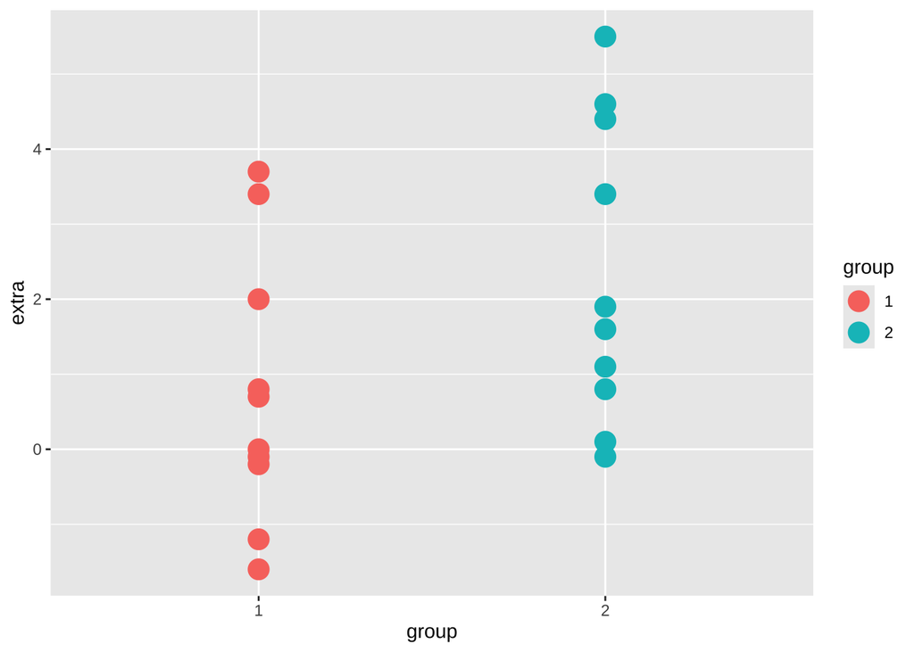

```r
sleep |>
  ggplot(aes(x = group, y = extra, color = group)) +
  geom_point(size = 5)
```

### 4.7.1 오버플롯팅 해결

> 데이터가 같은 지점에 중복될 때 자리를 비틀 수 있습니다

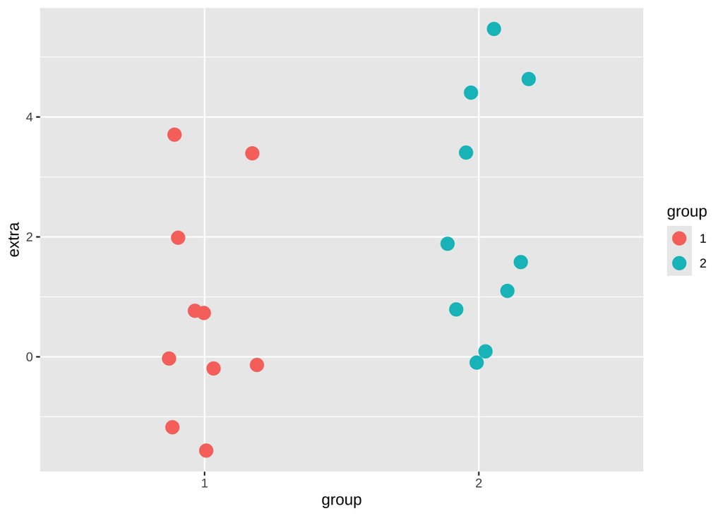

```r
sleep |>
  ggplot(aes(x = group, y = extra, color = group)) +
  geom_point(position = position_jitter(width = .2),
             size = 4)
```

#### 생각해볼 점

**소스 코드 확인하기**

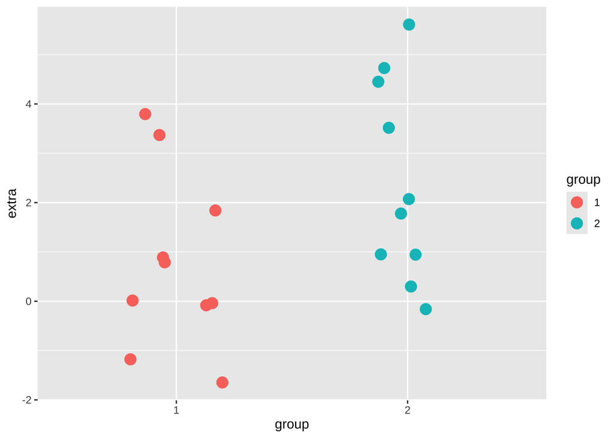

```r
sleep |>
  ggplot(aes(x = group, y = extra, color = group)) +
  geom_point(position = position_jitter(width = .2, height = .2),
             size = 4)
```

## 4.8 선으로 이어주기

> 실험자의 변화를 이어줍니다

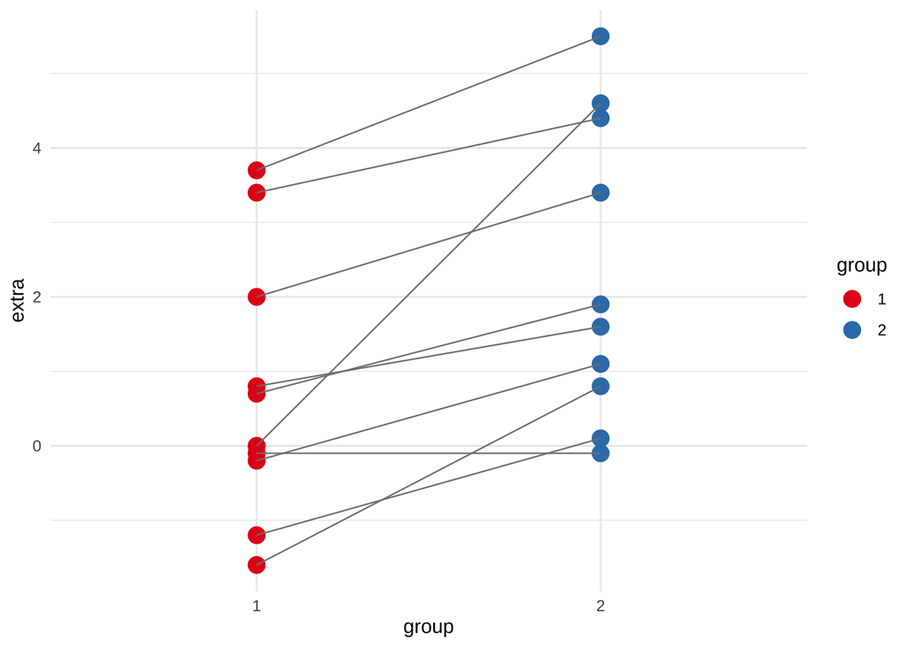

```r
ggplot(sleep, aes(x = group, y = extra)) +
  geom_point(aes(color = group), size = 4) +
  geom_line(color = "gray50", size = 0.4, aes(group = ID)) +
  theme_minimal() +
  scale_color_brewer(palette = 'Set1')
```

## 4.9 t.test

> 같은 사람이 두번씩 실험에 참여했으므로 대응표본을 적용합니다

> 대응표본 적용을 위해 pivot_wider로 변형해둔 sleep_wide_group 데이터셋을 사용합니다

```r
sleep_wide_group
```

```
# A tibble: 10 × 3
   ID    extra_1 extra_2
   <fct>   <dbl>   <dbl>
 1 1         0.7     1.9
 2 2        -1.6     0.8
 3 3        -0.2     1.1
 4 4        -1.2     0.1
 5 5        -0.1    -0.1
 6 6         3.4     4.4
 7 7         3.7     5.5
 8 8         0.8     1.6
 9 9         0       4.6
10 10        2       3.4
```

```r
t.test(sleep_wide_group$extra_1, sleep_wide_group$extra_2, paired = T)
```

```
    Paired t-test

data:  sleep_wide_group$extra_1 and sleep_wide_group$extra_2
t = -4.0621, df = 9, p-value = 0.002833
alternative hypothesis: true mean difference is not equal to 0
95 percent confidence interval:
 -2.4598858 -0.7001142
sample estimates:
mean difference
          -1.58
```

### 4.9.1 해석

1번약과 2번약의 수면 효과는 유의미하게 다릅니다 (2번약을 복용했을 때 수면시간이 1.58시간 더 증가합니다.

> mean difference: -1.58 (10명 환자의 평균 수면 시간 차이)

> t = -4.0621 (= mean difference / 표준오차)
> - 표준오차 대비 평균 차이가 4.06 배 크다는 의미이므로 실험 효과가 큽니다
> - 부호는 신경 쓰지 않고 크기(절대값 4.06)만 보면 됩니다

> p-value = 0.002833 (= 0.28%)
> - 이 실험결과 우연일 확률은 0.28%
> - 다른 표본으로 테스트해도 99.72% 유사하게 재현될 것입니다

> 95 percent confidence interval: -2.45 ~ -0.70
> - 구간 전체가 마이너스($-$) 영역에 존재하며, **`0`을 포함하지 않습니다.**
> - 여러차례 반복 실험을 할 경우 그 실험 결과의 95%는 0.7시간에서 2.45시간 더 수면 효과가 클 것입니다

# 5 통계가 복잡한 이유

**Tip**

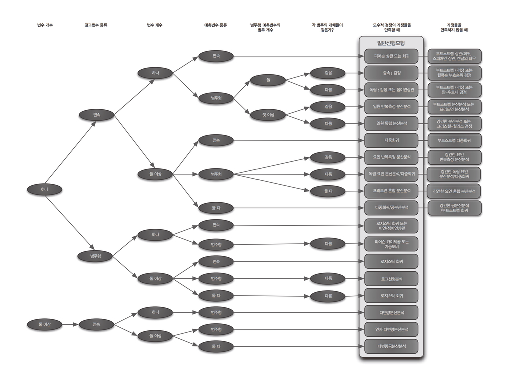

## 5.1 두 평균의 비교 정의

> 두 그룹의 차이가 통계적으로 유의미한지 알고자 할 때 수행

### 5.1.1 A와 B 그룹이 있을 경우

> 단일 표본: A의 평균과 어떤 값을 비교 (1번 수면약은 효과가 있는가?) 링크

> 독립 표본: A그룹의 평균과 B 그룹의 평균을 비교 (Gentoo vs Chinstrap 부리 길이 비교)

> 대응 표본: A그룹 평균의 Before, After를 비교 (1번약과 2번약의 수면효과는 유의미한가?)

## 5.2 문제

1. 1번약과 2번약의 수면 시간 평균을 구하시오

   ```
   # A tibble: 2 × 2
     group mean_extra
     <fct>      <dbl>
   1 1           0.75
   2 2           2.33
   ```

2. 평균을 비교했을 때 수면 시간 증가에 더욱 효과적인 약은 무엇인가요? (group1 or group2)

   ```r
   # 정답: group2
   # 2번 약의 평균 증가량이 2.33시간으로 1번 약의 0.75시간보다 큼
   ```

3. 참가자별로 수면 시간의 증감 평균을 구하시오

   ```
   # A tibble: 10 × 2
      ID    patient_mean
      <fct>        <dbl>
    1 1             1.3
    2 2            -0.4
    3 3             0.45
    4 4            -0.55
    5 5            -0.1
    6 6             3.9
    7 7             4.6
    8 8             1.2
    9 9             2.3
   10 10            2.7
   ```

4. 1번약과 2번약을 포함해 수면 시간이 가장 많이 증가한 참가자는 누구인가요?

   ```r
   sleep |>
     arrange(desc(extra)) |>
     slice(1)
   ```

   ```
     extra group ID
   1   5.5     2  7
   ```

5. 1번약과 2번약 모두 수면 시간이 증가하지 않은 (효과가 없는) 참가자는 누구인가요?

   ```
   # A tibble: 1 × 3
     ID    extra_1 extra_2
     <fct>   <dbl>   <dbl>
   1 5        -0.1    -0.1
   ```

#### [단일표본]

6. 1번약은 통계적으로 수면 시간 증대 효과가 있었나요?  
   (신뢰구간이 0을 지나간다는 것은 무엇을 의미하나요?)

   ```
       One Sample t-test

   data:  sleep_wide_group$extra_1
   t = 1.3257, df = 9, p-value = 0.2176
   alternative hypothesis: true mean is not equal to 0
   95 percent confidence interval:
    -0.5297804  2.0297804
   sample estimates:
   mean of x
        0.75
   ```

7. 2번약은 통계적으로 수면 시간 증대 효과가 있었나요?

   ```r
   t.test(sleep_wide_group$extra_2, mu = 0)
   ```

   ```
       One Sample t-test

   data:  sleep_wide_group$extra_2
   t = 3.6799, df = 9, p-value = 0.005076
   alternative hypothesis: true mean is not equal to 0
   95 percent confidence interval:
    0.8976775 3.7623225
   sample estimates:
   mean of x
        2.33
   ```

8. 1번약과 2번약을 통계적으로 검정할 때 사용해야 하는 t검정 기법은 무엇인가요?

   ```r
   #대응표본 t-검정 (Paired t-test)
   ```

# 6 treemap

```r
# install.packages("treemapify")     # 트리맵
library(treemapify)
```

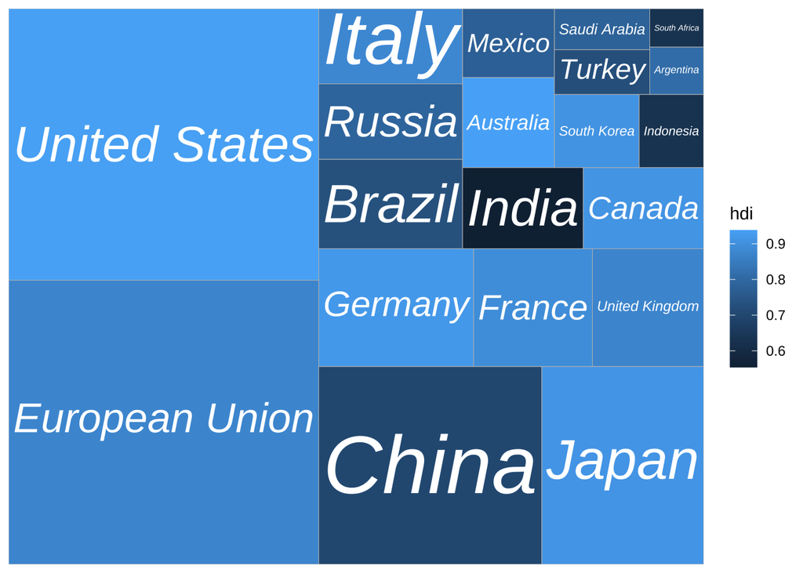

```r
ggplot(G20, aes(area = gdp_mil_usd, fill = hdi, label = country)) +
  geom_treemap() +
  geom_treemap_text(fontface = "italic", colour = "white", place = "centre",
                    grow = TRUE)
```